# Simulation: Comparing Single-Ordering Recovery

Ziang Zhang

## Question and design

Compare ordering recovery for **MPCurve, principal curves, GPLVM and Bayesian GPLVM** from shared PCA or Isomap initializations.

- **Design:** $N=200$; $P=12$ or 50; 30 independent replicates per condition.
- **Signal:** random cubic B-spline trajectories sharing one latent ordering; sample positions drawn from Uniform(0,1).
- **Noise:** Gaussian, with average variance SNR 16 or 1 ($\sigma=0.25$ or 1).
- **Pairing:** noise levels share curves, positions and standardized errors; the 50-feature extension retains the original 12 coefficient sets and adds 38.
- **Input and metric:** column-centered data without feature standardization; absolute Spearman correlation with truth (1 means recovery up to reversal).
- **Inclusion:** all generated datasets and finite fitted endpoints are retained.

Figure 1 shows replicate 1. Full generator settings and code are linked under Reproduction.

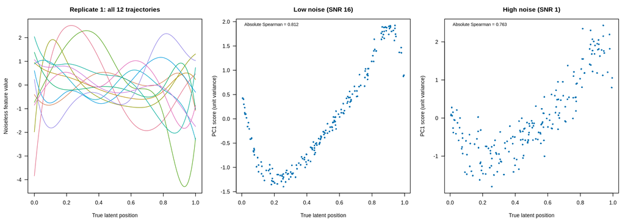

Figure 1. Replicate 1: all 12 noiseless trajectories (left) and shared PC1 initialization versus true sample position at SNR 16 (center) and SNR 1 (right). Scores retain their saved sign and spacing and are scaled to unit variance. Each point is one sample; absolute Spearman correlation allows reversal.

## Common initialization and methods

Each method uses the same PC1 direction. MPCurve discretizes its ranks into 50 quantile bins; principal curves start from the PC1 line; the GP methods use centered, unit-variance PC1 scores.

- **MPCurve:** frozen MPCurver 0.3.4, RW2 prior, learned feature noise and smoothness, adaptive position weights; CAVI ELBO tolerance $10^{-6}$, 2,000 sweeps.
- **Principal curves:** princurve 2.1.6, df=5, stretch=2; tolerance $10^{-6}$, 1,000 iterations.
- **GPLVM / Bayesian GPLVM:** GPy 1.13.2, native RBF+bias / RBF kernels; Bayesian GPLVM uses 50 inducing points. L-BFGS-B allows up to three blocks of 2,000 evaluations, continuing only after an evaluation-limit stop.

Stopping rules are method-specific. The initial embedding is shown as a baseline.

## Ordering recovery

The first comparison uses $P=12$ features (Figure 2 and Table 1).

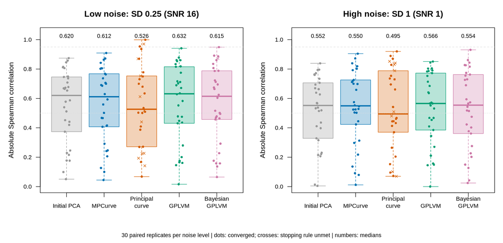

Figure 2. Absolute Spearman correlation between true sample position and inferred position over 30 replicates per noise condition. Boxes span Tukey hinges (approximate quartiles), center lines are medians, and whiskers extend to the most extreme values within 1.5 hinge ranges. Every finite endpoint is plotted: dots denote convergence or the PCA baseline; crosses denote an unmet stopping rule. Small horizontal offsets identify replicates and do not encode recovery. Numbers above boxes are medians. The dashed horizontal line marks 0.95 recovery and the dotted line marks 0.5. A global reversal is treated as equivalent.

Table 1. Median absolute Spearman and Kendall recovery over 30 replicates per noise condition.

| Method | Low noise (SNR 16) Median Spearman | Low noise (SNR 16) Median Kendall | High noise (SNR 1) Median Spearman | High noise (SNR 1) Median Kendall |
| --- | --- | --- | --- | --- |
| Initial PCA | 0.620 | 0.353 | 0.552 | 0.376 |
| MPCurve | 0.612 | 0.387 | 0.550 | 0.426 |
| Principal curve | 0.526 | 0.351 | 0.495 | 0.419 |
| GPLVM | 0.632 | 0.368 | 0.566 | 0.394 |
| Bayesian GPLVM | 0.615 | 0.459 | 0.554 | 0.421 |

With PCA starts, recovery varies widely across trajectories, and MPCurve and both GP methods remain close to the initial PCA (Figure 2, Table 1). Principal curves sometimes improve substantially but also lose recovery.

Stopping rules are met in 60/60 MPCurve, 42/60 principal-curve, 60/60 GPLVM and 59/60 Bayesian GPLVM fits. Exceptions are 18 principal-curve iteration caps and one Bayesian line-search error.

## Paired method differences

For $P=12$, paired mean differences from MPCurve range from about -0.014 to +0.010, each smaller than its Monte Carlo SE (Figure 3, Table 2). These 30 replicates show no consistent comparator advantage under PCA initialization.

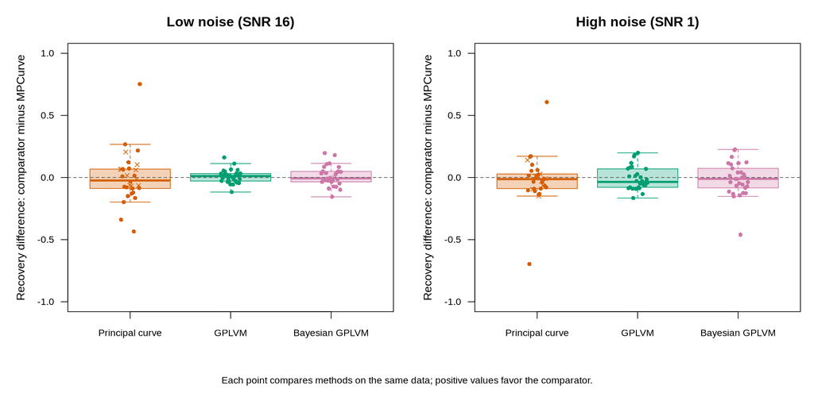

Figure 3. Paired differences in absolute Spearman recovery, computed as comparator minus MPCurve on the same dataset. Positive values favor the comparator; the dashed line is zero difference. Box and whisker conventions match Figure 2. Each point is one replicate, and a cross marks a comparator that did not meet its stopping rule. All endpoints are retained.

Table 2. Mean and median paired differences in absolute Spearman recovery (comparator minus MPCurve), over 30 replicates.

| Comparator | Low noise (SNR 16) Mean difference | Low noise (SNR 16) Median difference | High noise (SNR 1) Mean difference | High noise (SNR 1) Median difference |
| --- | --- | --- | --- | --- |
| Bayesian GPLVM | 0.010 | -0.006 | -0.013 | -0.011 |
| GPLVM | 0.009 | 0.012 | -0.007 | -0.035 |
| Principal curve | -0.002 | -0.024 | -0.014 | -0.013 |

## Increasing feature count to 50

Add 38 independent features to each replicate, retaining its sample positions, original coefficients and standardized errors. Rescale the full signal to average variance one and recompute PCA; $N$, SNR and fitting settings stay fixed (Figure 4, Table 3). This rescaling changes the original features’ amplitudes.

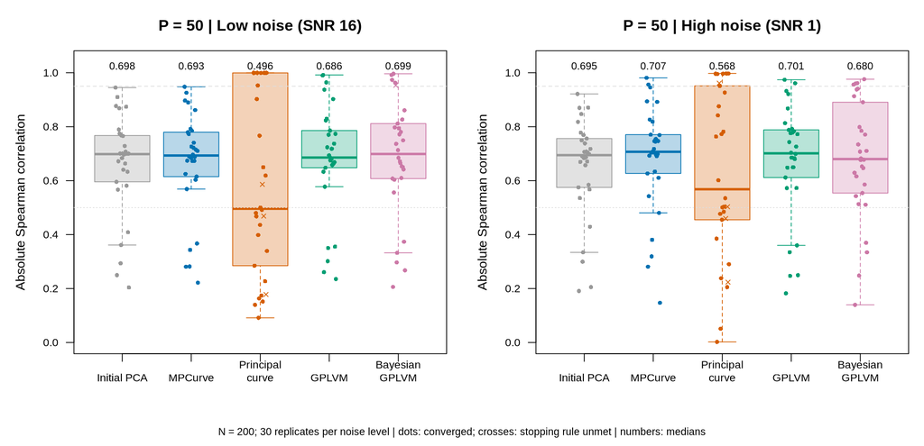

Figure 4. Ordering recovery with 50 features, 200 samples and 30 replicates per noise condition. Absolute Spearman correlation allows a global reversal. Boxes, whiskers and reference lines follow Figure 2; numbers above boxes are medians. Every finite endpoint is retained. Crosses indicate that the fitting stopping rule was not met.

Table 3. Median absolute Spearman recovery with 12 and 50 features, over 30 paired replicates.

| Method | Low noise (SNR 16) Median, P=12 | Low noise (SNR 16) Median, P=50 | High noise (SNR 1) Median, P=12 | High noise (SNR 1) Median, P=50 |
| --- | --- | --- | --- | --- |
| Initial PCA | 0.620 | 0.698 | 0.552 | 0.695 |
| MPCurve | 0.612 | 0.693 | 0.550 | 0.707 |
| Principal curve | 0.526 | 0.496 | 0.495 | 0.568 |
| GPLVM | 0.632 | 0.686 | 0.566 | 0.701 |
| Bayesian GPLVM | 0.615 | 0.699 | 0.554 | 0.680 |

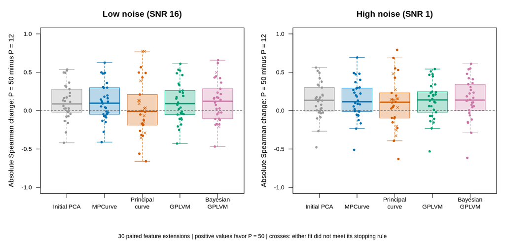

Figure 5. Within-replicate changes in absolute Spearman recovery after extending from 12 to 50 features. Positive values favor 50 features; the dashed line marks no change. Boxes and whiskers use the Figure 2 convention. A cross indicates that either feature-count fit did not meet its stopping rule. The PCA column shows how the initial ordering itself changes when using the additional features.

Eight principal-curve fits hit the iteration cap and one Bayesian GPLVM fit has a line-search error; all endpoints are retained.

### Fitting time

Table 4. Median fitting time in seconds with 12 and 50 features, over 30 replicates, including fits that reach the iteration limit.

| Method | Low noise (SNR 16) Seconds, P=12 | Low noise (SNR 16) Seconds, P=50 | High noise (SNR 1) Seconds, P=12 | High noise (SNR 1) Seconds, P=50 |
| --- | --- | --- | --- | --- |
| MPCurve | 0.12 | 0.26 | 0.47 | 1.22 |
| Principal curve | 1.03 | 3.32 | 1.13 | 2.42 |
| GPLVM | 2.93 | 2.53 | 1.83 | 0.64 |
| Bayesian GPLVM | 9.95 | 15.84 | 2.33 | 2.05 |

At $P=50$, MPCurve is fastest at low noise (median 0.26 s); GPLVM is fastest at high noise (0.64 s versus MPCurve’s 1.22 s; Table 4). Times include setup and fitting, exclude shared simulation/PCA, and use one BLAS thread per fit. They reflect method-specific stopping rules and concurrent runs; full timing boundaries are in the experiment READMEs.

## Common Isomap initialization

Rerun all methods on the same 120 datasets using **Isomap with fixed $k=15$**, Euclidean neighbor distances and one-dimensional classical MDS. All graphs are connected. The neighborhood size is not tuned using recovery.

MPCurve bins the shared coordinate; GP methods use it directly. Principal curves smooth features against Isomap (df=5), then project onto that curve, which can change the actual starting order (Table 6). Seeds and other fitting settings match the PCA runs.

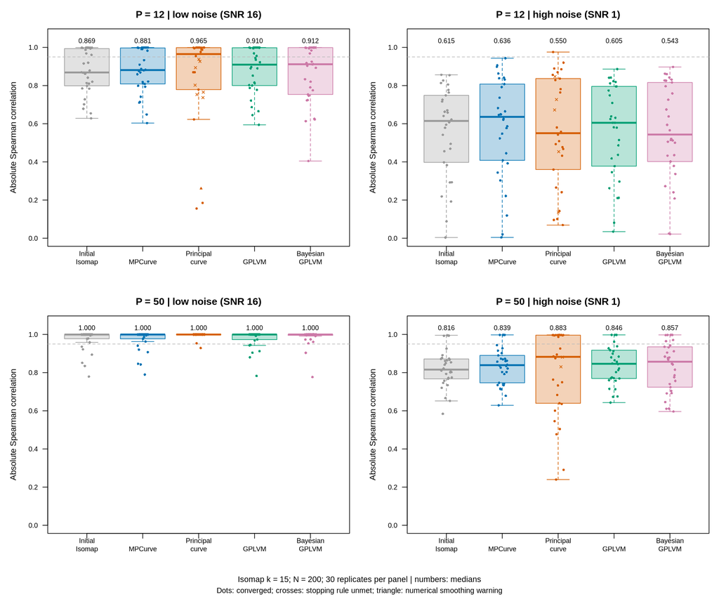

Figure 6. Absolute Spearman ordering recovery from common Isomap k=15 starts, with N=200 and 30 replicates in each panel. Rows show P=12 and P=50; columns show low and high noise. Boxes span Tukey hinges, center lines show medians, and whiskers extend to the most extreme value within 1.5 hinge ranges. All endpoints appear as dots or, when the stopping rule is unmet, crosses. A triangle marks one principal-curve fit with a numerical smoothing warning. The dashed line marks 0.95 recovery. Numbers above boxes are medians; global reversal is allowed.

Table 5. Median absolute Spearman recovery from PCA and Isomap starts on the same 30 datasets per condition. Initial-embedding rows compare the starts themselves.

| P | Method | Low noise (SNR 16) PCA median | Low noise (SNR 16) Isomap median | High noise (SNR 1) PCA median | High noise (SNR 1) Isomap median |
| --- | --- | --- | --- | --- | --- |
| 12 | Initial embedding | 0.6203 | 0.8687 | 0.5521 | 0.6146 |
| 12 | MPCurve | 0.6116 | 0.8811 | 0.5496 | 0.6360 |
| 12 | Principal curve | 0.5263 | 0.9649 | 0.4946 | 0.5504 |
| 12 | GPLVM | 0.6316 | 0.9095 | 0.5656 | 0.6049 |
| 12 | Bayesian GPLVM | 0.6146 | 0.9116 | 0.5542 | 0.5433 |
| 50 | Initial embedding | 0.6984 | 0.9997 | 0.6946 | 0.8159 |
| 50 | MPCurve | 0.6933 | 0.9997 | 0.7070 | 0.8392 |
| 50 | Principal curve | 0.4959 | 0.9997 | 0.5682 | 0.8828 |
| 50 | GPLVM | 0.6856 | 0.9997 | 0.7013 | 0.8463 |
| 50 | Bayesian GPLVM | 0.6990 | 0.9997 | 0.6800 | 0.8572 |

Table 6. Principal-curve median absolute Spearman recovery after projecting the Isomap start onto a curve and after fitting, over 30 replicates.

| P | Low noise (SNR 16) Initial median | Low noise (SNR 16) Final median | High noise (SNR 1) Initial median | High noise (SNR 1) Final median |
| --- | --- | --- | --- | --- |
| 12 | 0.8762 | 0.9649 | 0.6166 | 0.5504 |
| 50 | 0.9997 | 0.9997 | 0.8435 | 0.8828 |

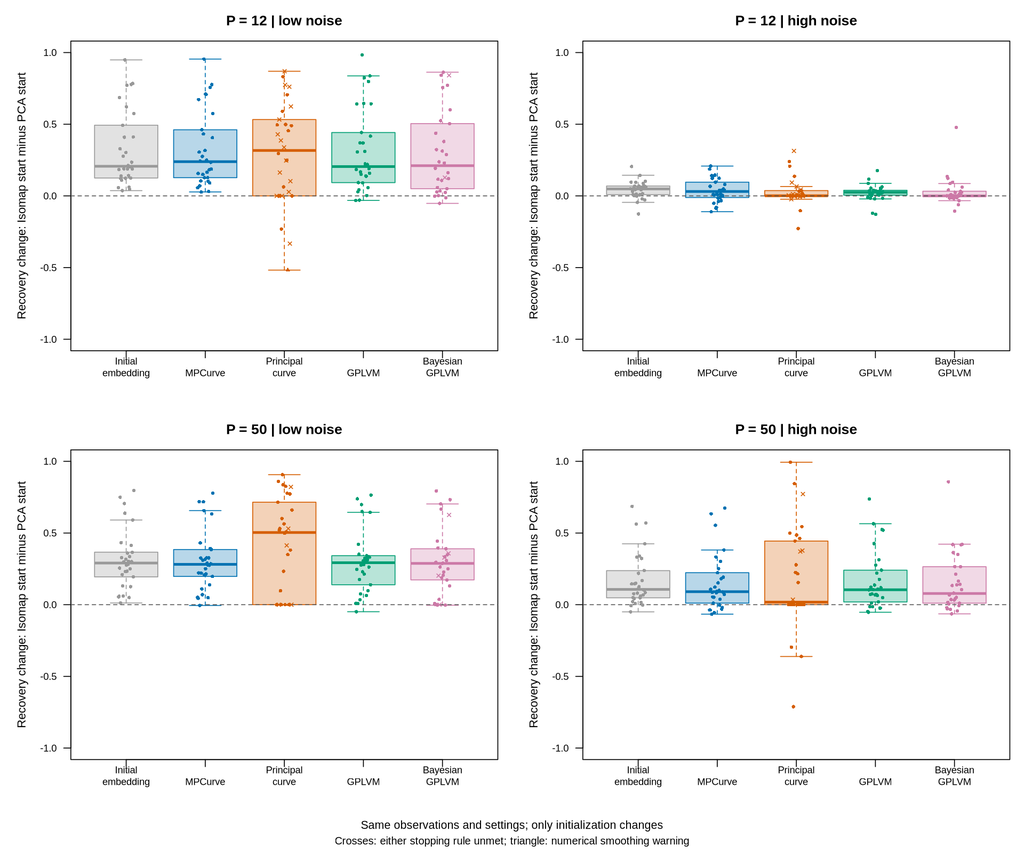

Figure 7. Paired change in absolute Spearman recovery after replacing PCA with Isomap initialization on the same data. Positive values favor Isomap; the dashed line marks no change. The first column compares the embeddings themselves, and the other columns compare fitted endpoints. Boxes and whiskers follow Figure 6. Crosses indicate that either the PCA or the Isomap fit did not meet its stopping rule; a triangle marks a numerical smoothing warning. Each panel contains 30 paired replicates.

Isomap improves low-noise recovery (Figures 6 and 7, Table 5). MPCurve medians rise from 0.612 to 0.881 at $P=12$ and from 0.693 to 0.9997 at $P=50$. At $P=50$, all four fitted medians are about 0.9997; recovery $\geq0.95$ occurs in 24/30, 29/30, 24/30 and 28/30 fits for MPCurve, principal curves, GPLVM and Bayesian GPLVM, respectively.

At high noise, MPCurve has the highest median at $P=12$ (0.636). Principal curves have the highest median at $P=50$ (0.883), but a lower mean than MPCurve (0.803 versus 0.834) because some replicates deteriorate substantially.

All 480 endpoints are finite. Unmet stopping rules comprise 16 principal-curve iteration caps and five Bayesian line-search errors. One principal-curve fit ($P=12$, low noise, replicate 22) has a numerical smoothing warning and uses df=1 instead of 5; triangles flag it in the plots.

### Runtime with Isomap

Table 7. Median Isomap runtime over 30 replicates: fitting alone and total including initialization. Total adds embedding time and, for principal curves, initial-curve construction. Each fit uses one BLAS thread.

| P | Method | Low noise (SNR 16) Fit seconds | Low noise (SNR 16) Total seconds | High noise (SNR 1) Fit seconds | High noise (SNR 1) Total seconds |
| --- | --- | --- | --- | --- | --- |
| 12 | MPCurve | 0.17 | 0.22 | 0.48 | 0.52 |
| 12 | Principal curve | 0.69 | 0.78 | 0.88 | 0.93 |
| 12 | GPLVM | 1.82 | 1.86 | 1.68 | 1.73 |
| 12 | Bayesian GPLVM | 4.70 | 4.74 | 2.00 | 2.04 |
| 50 | MPCurve | 0.43 | 0.51 | 1.34 | 1.42 |
| 50 | Principal curve | 2.06 | 2.20 | 2.36 | 2.50 |
| 50 | GPLVM | 0.77 | 0.84 | 0.68 | 0.76 |
| 50 | Bayesian GPLVM | 4.26 | 4.34 | 2.07 | 2.15 |

With initialization cost included (Table 7), median MPCurve time is 0.22/0.52 seconds at $P=12$ and 0.51/1.42 seconds at $P=50$ (low/high noise). MPCurve is fastest in three conditions; at $P=50$ and high noise, GPLVM is faster at 0.76 seconds total. The shared Isomap computation takes a median 0.04–0.08 seconds per dataset.

## Reproduction

This page reads saved results without refitting. Code, generator/optimizer settings, seeds, versions, input hashes and saved fits are available here:

- [PCA comparison, P=12](https://github.com/AgueroZZ/InferOrder/tree/master/experiments/m1_bspline_comparison)
- [Paired P=50 extension](https://github.com/AgueroZZ/InferOrder/tree/master/experiments/m1_bspline_comparison_p50)
- [Isomap comparison](https://github.com/AgueroZZ/InferOrder/tree/master/experiments/m1_bspline_isomap)

MPCurver source is frozen at `15f2b0bbe5dfa61cd46da5160b2bc251e75a0475`. Reproduction checks reconstruct inputs, verify shared starts and recompute recovery from saved coordinates.